# Autoencoder Weights & Biases Analysis

```
Author:
    Zach Wolpe
    zachcolinwolpe@gmail.com
    www.zachwolpe.com
```

In analysing the cause of the autoencoders sampling bias, we inspect he **Weights** and **Biases** for every epoch.

```python
import numpy as np
import pandas as pd
import matplotlib.pyplot as plt
import joypy
from LearnParameters import LearnParameters
```

```python
%matplotlib inline
import sys, os
%env THEANO_FLAGS=device=cpu,floatX=float64
import theano


from collections import OrderedDict
from copy import deepcopy
import numpy as np
import pandas as pd
from time import time
from sklearn.feature_extraction.text import TfidfVectorizer, CountVectorizer
from sklearn.datasets import fetch_20newsgroups
import matplotlib.pyplot as plt
import seaborn as sns
from theano import shared
import theano.tensor as tt
from theano.sandbox.rng_mrg import MRG_RandomStreams

import pymc3 as pm
from pymc3 import math as pmmath
from pymc3 import Dirichlet
from pymc3.distributions.transforms import t_stick_breaking
plt.style.use('seaborn-darkgrid')

import warnings
warnings.filterwarnings("ignore")

import warnings
warnings.filterwarnings("ignore")
```

```
env: THEANO_FLAGS=device=cpu,floatX=float64
```

# Weights & Biases

The function below return the weights and biases for a certain vocab size, for a certain number of epochs.

## Additional Callback

This is achieved by writing a callback that stories these results in a dictionary per iteration.

```python
def return_weights_biases(no_epochs,n_topics,n_words):
    """
    Return: the weights & biases for a certain number of Epochs
    """
    # The number of words in the vocabulary
    n_words = n_words
    t0 = time()
    dataset = fetch_20newsgroups(shuffle=True, random_state=1, remove=('headers', 'footers', 'quotes'))
    data_samples = dataset.data
    # Use tf (raw term count) features for LDA.
    tf_vectorizer = CountVectorizer(max_df=0.95, min_df=2, max_features=n_words, stop_words='english')
    t0 = time()
    tf = tf_vectorizer.fit_transform(data_samples)
    feature_names = tf_vectorizer.get_feature_names()
    n_samples_tr = round(tf.shape[0] * 0.7) # testing on 70%
    n_samples_te = tf.shape[0] - n_samples_tr
    docs_tr = tf[:n_samples_tr, :]
    docs_te = tf[n_samples_tr:, :]
    n_tokens = np.sum(docs_tr[docs_tr.nonzero()])


    n_topics = n_topics
    def logp_lda_doc(beta, theta):
      """Returns the log-likelihood function for given documents.

      K : number of topics in the model
      V : number of words (size of vocabulary)
      D : number of documents (in a mini-batch)

      Parameters
      ----------
      beta : tensor (K x V)
          Word distribution.
      theta : tensor (D x K)
          Topic distributions for the documents.
      """

      def ll_docs_f(docs):

        dixs, vixs = docs.nonzero()
        vfreqs = docs[dixs, vixs]
        ll_docs = vfreqs * pmmath.logsumexp(
              tt.log(theta[dixs]) + tt.log(beta.T[vixs]), axis=1).ravel()

        # Per-word log-likelihood times no. of tokens in the whole dataset
        return tt.sum(ll_docs) / (tt.sum(vfreqs)+1e-9) * n_tokens

      return ll_docs_f

    # we have sparse dataset. It's better to have dence batch so that all words accure there
    minibatch_size = 128

    # defining minibatch
    doc_t_minibatch = pm.Minibatch(docs_tr.toarray(), minibatch_size)
    doc_t = shared(docs_tr.toarray()[:minibatch_size])

    with pm.Model() as model:
      theta = Dirichlet('theta', a=pm.floatX((1.0 / n_topics) * np.ones((minibatch_size, n_topics))),
                       shape=(minibatch_size, n_topics), transform=t_stick_breaking(1e-9),
                       # do not forget scaling
                       total_size = n_samples_tr)
      beta = Dirichlet('beta', a=pm.floatX((1.0 / n_topics) * np.ones((n_topics, n_words))),
                     shape=(n_topics, n_words), transform=t_stick_breaking(1e-9))
      # Note, that we defined likelihood with scaling, so here we need no additional `total_size` kwarg
      doc = pm.DensityDist('doc', logp_lda_doc(beta, theta), observed=doc_t)

    class LDAEncoder:
      """Encode (term-frequency) document vectors to variational means and (log-transformed) stds.
      """
      def __init__(self, n_words, n_hidden, n_topics, p_corruption=0, random_seed=1):
        rng = np.random.RandomState(random_seed)
        self.n_words = n_words
        self.n_hidden = n_hidden
        self.n_topics = n_topics
        self.w0 = shared(0.01 * rng.randn(n_words, n_hidden).ravel(), name='w0')

    class LDAEncoder:
        """Encode (term-frequency) document vectors to variational means and (log-transformed) stds.
        """
        def __init__(self, n_words, n_hidden, n_topics, p_corruption=0, random_seed=1):
            rng = np.random.RandomState(random_seed)
            self.n_words = n_words
            self.n_hidden = n_hidden
            self.n_topics = n_topics
            self.w0 = shared(0.01 * rng.randn(n_words, n_hidden).ravel(), name='w0')
            self.b0 = shared(0.01 * rng.randn(n_hidden), name='b0')
            self.w1 = shared(0.01 * rng.randn(n_hidden, 2 * (n_topics - 1)).ravel(), name='w1')
            self.b1 = shared(0.01 * rng.randn(2 * (n_topics - 1)), name='b1')
            self.rng = MRG_RandomStreams(seed=random_seed)
            self.p_corruption = p_corruption

        def encode(self, xs):
            if 0 < self.p_corruption:
                dixs, vixs = xs.nonzero()
                mask = tt.set_subtensor(
                    tt.zeros_like(xs)[dixs, vixs],
                    self.rng.binomial(size=dixs.shape, n=1, p=1-self.p_corruption)
                )
                xs_ = xs * mask
            else:
                xs_ = xs

            w0 = self.w0.reshape((self.n_words, self.n_hidden))
            w1 = self.w1.reshape((self.n_hidden, 2 * (self.n_topics - 1)))
            hs = tt.tanh(xs_.dot(w0) + self.b0)
            zs = hs.dot(w1) + self.b1
            zs_mean = zs[:, :(self.n_topics - 1)]
            zs_rho = zs[:, (self.n_topics - 1):]
            return {'mu': zs_mean, 'rho':zs_rho}

        def get_params(self):
            return [self.w0, self.b0, self.w1, self.b1]

    encoder = LDAEncoder(n_words=n_words, n_hidden=100, n_topics=n_topics, p_corruption=0.0)
    local_RVs = OrderedDict([(theta, encoder.encode(doc_t))])
    local_RVs
    encoder_params = encoder.get_params()
    encoder_params



    ############################################### CALLBACK ###############################################
    store_weights_biases = []


    def my_callback(a,h,i):
        store_weights_biases.append(encoder.get_params())

    η = .1
    s = shared(η)
    def reduce_rate(a, h, i):
        s.set_value(η/((i/minibatch_size)+1)**.7)

    with model:
        approx = pm.MeanField(local_rv=local_RVs)
        approx.scale_cost_to_minibatch = False
        inference = pm.KLqp(approx)
    inference.fit(no_epochs, callbacks=[reduce_rate, my_callback], obj_optimizer=pm.sgd(learning_rate=s),
                  more_obj_params=encoder_params, total_grad_norm_constraint=200,
                  more_replacements={doc_t:doc_t_minibatch})

    return store_weights_biases
```

# Call the Function

view the results for $100$ epochs:

- for varying word vocabulary sizes
  - for varying topic sizes

```python
weights_biases = []

for i in [50,100,500,1000,2000,5000]:
    # for varying vocab sizes

    sub_list = []
    for j in [5,10,15,20]:
        # varying topic sized
        sub_list.append(return_weights_biases(100,j,i))

    weights_biases.append(sub_list)
```

```
Finished [100%]: Average Loss = 6.4946e+05
Finished [100%]: Average Loss = 7.1772e+05
Finished [100%]: Average Loss = 7.8158e+05
Finished [100%]: Average Loss = 8.2487e+05
Finished [100%]: Average Loss = 9.0833e+05
Finished [100%]: Average Loss = 9.7263e+05
Finished [100%]: Average Loss = 1.0244e+06
Finished [100%]: Average Loss = 1.0742e+06
Finished [100%]: Average Loss = 2.0256e+06
Finished [100%]: Average Loss = 2.1172e+06
Finished [100%]: Average Loss = 2.1302e+06
Finished [100%]: Average Loss = 2.1943e+06
Finished [100%]: Average Loss = 2.8786e+06
Finished [100%]: Average Loss = 2.8935e+06
Finished [100%]: Average Loss = 3.019e+06
Finished [100%]: Average Loss = 3.0434e+06
Finished [100%]: Average Loss = 3.9281e+06
Finished [100%]: Average Loss = 3.9424e+06
Finished [100%]: Average Loss = 4.0316e+06
Finished [100%]: Average Loss = 4.1152e+06
Finished [100%]: Average Loss = 5.3292e+06
Finished [100%]: Average Loss = 5.4758e+06
Finished [100%]: Average Loss = 5.6547e+06
Finished [100%]: Average Loss = 5.7546e+06
```

# Interpretating Results

The results take the shape $(6, 4, 100, 4)$ which can be partitioned as:

- $1^{st}$ Dimension $(6)$: for $6$ vocab sizes
- $2^{nd}$ Dimension $(4)$: for $4$ topic sizes
- $3^{nd}$ Dimension $(100)$: for $100$ for $100$ epochs
- $4^{th}$ Dimension $(4)$: the $4$ variables $\{w_0,b_0,w_1,b_1\}$ for each variant

### {w0,w1,b0,b1} Dimensionality

The dimensionality can be confusion. Each weight $\{w_0\}$ constitutes

$$w_0: (\text{n vocab words} \times \text{ n hidden layers})$$

with each corresponding bias $\{b_0\}$ consisting of

$$b_0: (1 \times \text{ n hidden layers})$$

where this neural architecture consists of $100$ hidden layers.

The second weight $\{w_1\}$ follows the structure of the learned parameters from the $2*(K-1)$ simplex - where $K$ is the number of topics learned - $\times$ the number of hidden layers. With each parameter value associated with a bias.

$$w_1: (2*(K-1) \times \text{ n hidden layers })$$$$b_1: (2*(K-1) \times 1)$$

```python
print('\n Dimensionality:')
np.shape(weights_biases)
```

```
 Dimensionality:
```

```
(6, 4, 100, 4)
```

```python
print("Example: w=50 k=5")
print('\n w0(0) for (50 x 100) (words x layers): ', weights_biases[0][0][0][0].get_value().shape)
print('\n b0(0) for (50 x 100) (1 x layers): ', np.array(weights_biases[0][0])[0][1].get_value().shape)

print('\n w1(0) for (50 x 100) (words x layers): ', weights_biases[0][0][0][2].get_value().shape)
print('\n b1(0) for (50 x 100) (words x layers): ', np.array(weights_biases[0][0])[0][3].get_value().shape)
```

```
Example: w=50 k=5

 w0(0) for (50 x 100) (words x layers):  (5000,)

 b0(0) for (50 x 100) (1 x layers):  (100,)

 w1(0) for (50 x 100) (words x layers):  (800,)

 b1(0) for (50 x 100) (words x layers):  (8,)
```

# Distribution of Epochs

### Complex Model

Vocab: $w = 5000$

Topics: $K=20$

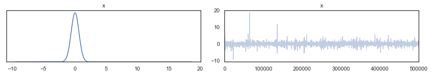

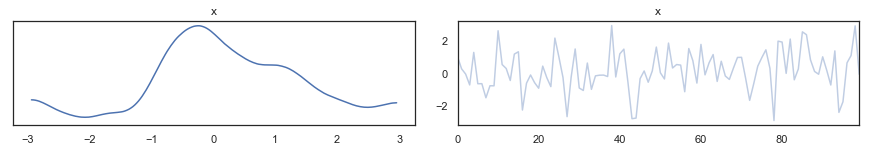

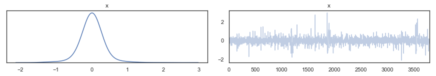

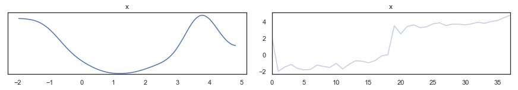

```python
for j in range(4):
    pm.plots.traceplot(weights_biases[5][3][0][j].get_value());
```

### Simple Model

Topics: $K=5$

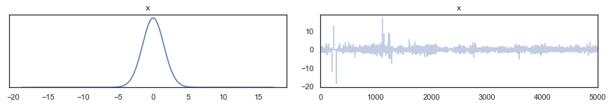

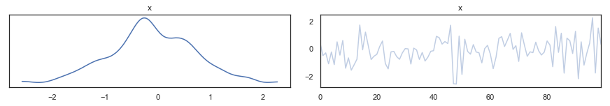

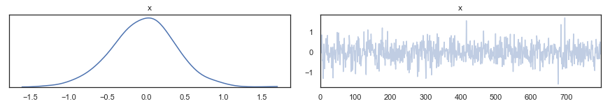

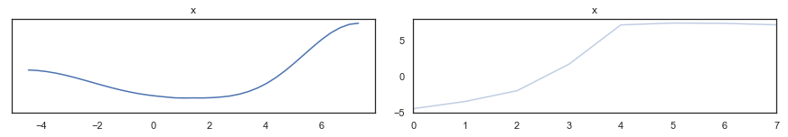

```python
for j in range(4):
    pm.plots.traceplot(weights_biases[0][0][0][j].get_value(), compact=True);
```

# Distributions of Parameters over W words

## W0: Weight 0

Note $w_0$ becomes narrower as words increase (across plots), and there is almost not change effect on the change in $K$ (within plots)

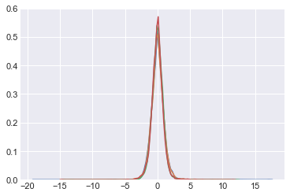

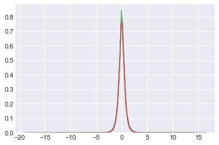

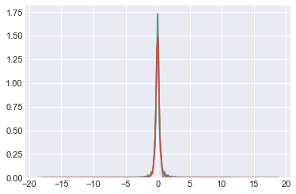

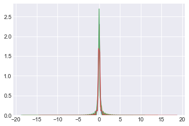

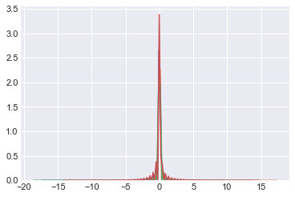

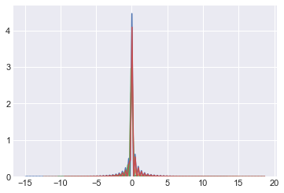

```python
import seaborn as sns
plt.style.use('seaborn-darkgrid')

for i in range(6):
    fig, ax = plt.subplots(1);
    for j in range(4):
        sns.kdeplot(weights_biases[i][j][0][0].get_value());
```

## B0: Bias 0

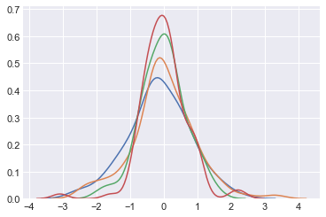

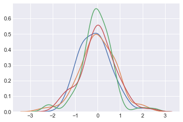

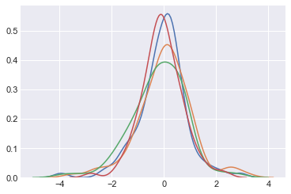

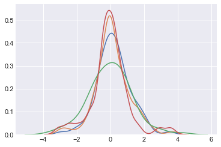

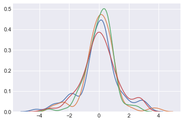

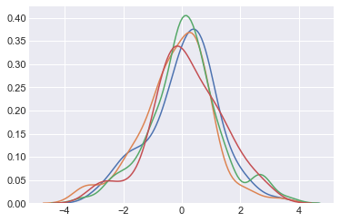

```python
for i in range(6):
    fig, ax = plt.subplots(1);
    for j in range(4):
        sns.kdeplot(weights_biases[i][j][0][1].get_value());
```

## W1: Weight 1

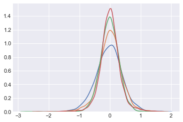

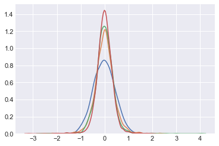

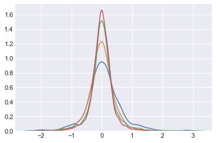

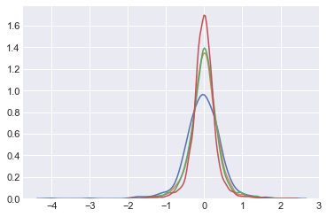

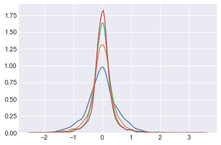

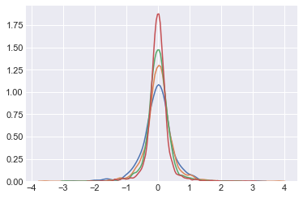

```python
for i in range(6):
    fig, ax = plt.subplots(1);
    for j in range(4):
        sns.kdeplot(weights_biases[i][j][0][2].get_value());
```